# Data Analyst Nanodegree Project 4: Red Wine Quality Evaluation

Submitted by S. Teodorovich

## Introduction

I enjoy red wine but have no idea how to properly determine what makes a wine good or not other than the purely subjective application of “I don’t know if this is good wine, but I like it.” With that in mind, I took this dataset in the hope that it might give me a bit more insight into the actual physical properties that help determine wine quality.

The dataset was downloaded from https://s3.amazonaws.com/udacity-hosted-downloads/ud651/wineQualityReds.csv.

We begin by loading necessary packages & libraries, followed by reading the Data:

# Section 1: Univariate Plots

A good first step is always to do get a brief summary of the data set. I’ll start with the variable names, followed by a summary of the variable data types, and last with an example of the actual data in tabular form:

```
##  [1] "X"                    "fixed.acidity"        "volatile.acidity"
##  [4] "citric.acid"          "residual.sugar"       "chlorides"
##  [7] "free.sulfur.dioxide"  "total.sulfur.dioxide" "density"
## [10] "pH"                   "sulphates"            "alcohol"
## [13] "quality"
```

We see that the first variable is called *X*, which is just an identifier and not actually relevant data. With that in mind, we can eliminate it from the dataset:

```
##  [1] "fixed.acidity"        "volatile.acidity"     "citric.acid"
##  [4] "residual.sugar"       "chlorides"            "free.sulfur.dioxide"
##  [7] "total.sulfur.dioxide" "density"              "pH"
## [10] "sulphates"            "alcohol"              "quality"
```

*X* Has been removed. Now to go ahead and run the rest of the dataset summaries:

```
## 'data.frame':    1599 obs. of  12 variables:
##  $ fixed.acidity       : num  7.4 7.8 7.8 11.2 7.4 7.4 7.9 7.3 7.8 7.5 ...
##  $ volatile.acidity    : num  0.7 0.88 0.76 0.28 0.7 0.66 0.6 0.65 0.58 0.5 ...
##  $ citric.acid         : num  0 0 0.04 0.56 0 0 0.06 0 0.02 0.36 ...
##  $ residual.sugar      : num  1.9 2.6 2.3 1.9 1.9 1.8 1.6 1.2 2 6.1 ...
##  $ chlorides           : num  0.076 0.098 0.092 0.075 0.076 0.075 0.069 0.065 0.073 0.071 ...
##  $ free.sulfur.dioxide : num  11 25 15 17 11 13 15 15 9 17 ...
##  $ total.sulfur.dioxide: num  34 67 54 60 34 40 59 21 18 102 ...
##  $ density             : num  0.998 0.997 0.997 0.998 0.998 ...
##  $ pH                  : num  3.51 3.2 3.26 3.16 3.51 3.51 3.3 3.39 3.36 3.35 ...
##  $ sulphates           : num  0.56 0.68 0.65 0.58 0.56 0.56 0.46 0.47 0.57 0.8 ...
##  $ alcohol             : num  9.4 9.8 9.8 9.8 9.4 9.4 9.4 10 9.5 10.5 ...
##  $ quality             : int  5 5 5 6 5 5 5 7 7 5 ...
```

```
##   fixed.acidity volatile.acidity citric.acid residual.sugar chlorides
## 1           7.4             0.70        0.00            1.9     0.076
## 2           7.8             0.88        0.00            2.6     0.098
## 3           7.8             0.76        0.04            2.3     0.092
## 4          11.2             0.28        0.56            1.9     0.075
## 5           7.4             0.70        0.00            1.9     0.076
## 6           7.4             0.66        0.00            1.8     0.075
##   free.sulfur.dioxide total.sulfur.dioxide density   pH sulphates alcohol
## 1                  11                   34  0.9978 3.51      0.56     9.4
## 2                  25                   67  0.9968 3.20      0.68     9.8
## 3                  15                   54  0.9970 3.26      0.65     9.8
## 4                  17                   60  0.9980 3.16      0.58     9.8
## 5                  11                   34  0.9978 3.51      0.56     9.4
## 6                  13                   40  0.9978 3.51      0.56     9.4
##   quality
## 1       5
## 2       5
## 3       5
## 4       6
## 5       5
## 6       5
```

The first thing I see is that both *Free* and *Total Sulphur Dioxide* are listed as “num” yet in the sample it seems they are “int”. It might be a good idea to check if this is correct or not:

```
## [1] 40.5  5.5 37.5 37.5
```

```
## [1] 77.5 77.5
```

It seems that these are indeed numbers.

At this point we should begin to look at the variables in a bit more detail by creating histograms to check their distribution and shape.

First, we’ll give quality a lookover to see just how these wines stack up:

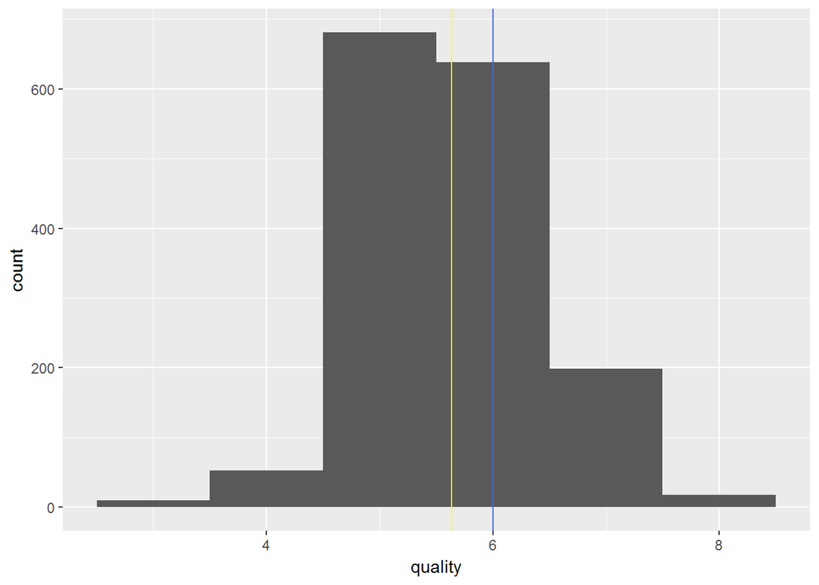

```
##    Min. 1st Qu.  Median    Mean 3rd Qu.    Max.
##   3.000   5.000   6.000   5.636   6.000   8.000
```

Wine quality is scored on a scale of 1 - 10, but all of our wines fall in the range of 3 - 8, suggesting that none of these wines were either exceptionally good or bad. Further, the distribution does somewhat approximate a normal curve, which is expected as one would think that there would be relatively few good or bad wines compared to medium quality.

Now let’s start looking at the variables that describe the physio-chemical components of the wine, and which will serve as the focus of our efforts to determine what influences quality. We’ll begin with *Residual Sugar*:

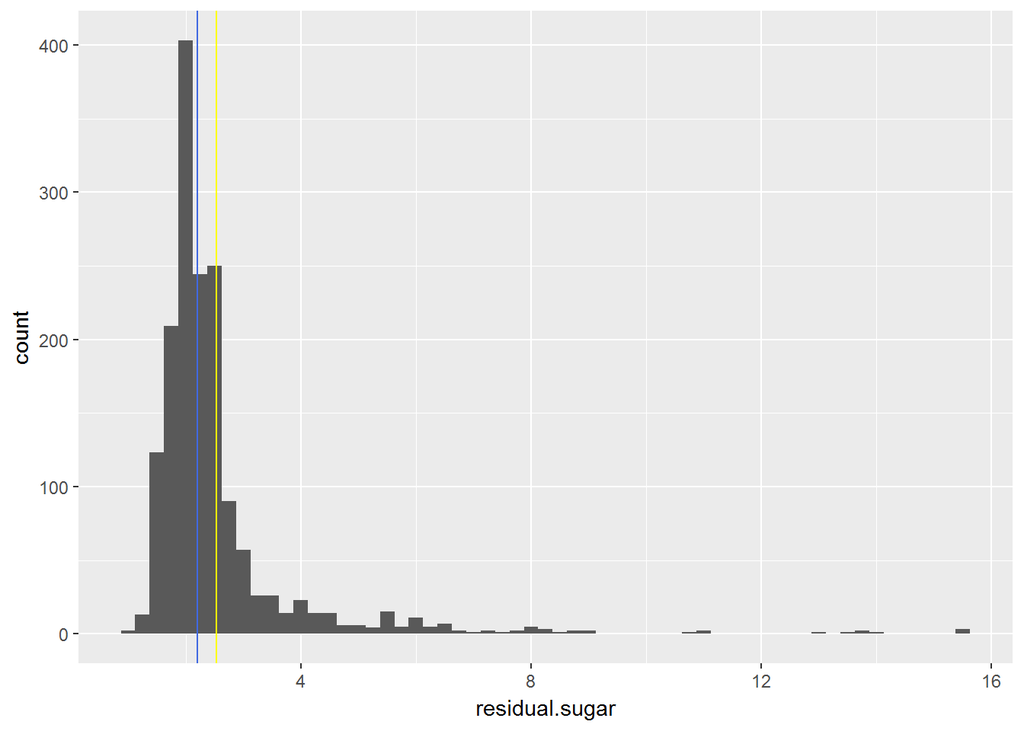

```
##    Min. 1st Qu.  Median    Mean 3rd Qu.    Max.
##   0.900   1.900   2.200   2.539   2.600  15.500
```

Now that is a positively skewed distribution with a very long tail. It may be more helpful to chop this a bit to remove some of the extreme outliers and take a peek at only the bottom 95%

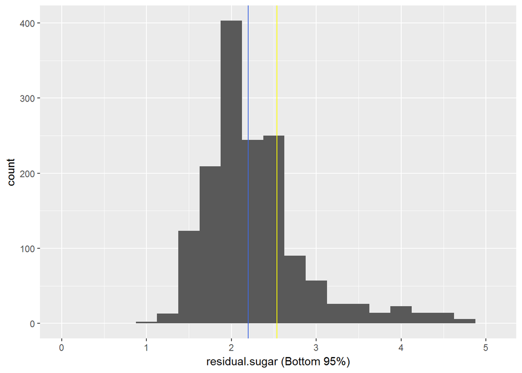

```
##    Min. 1st Qu.  Median    Mean 3rd Qu.    Max.
##   0.900   1.900   2.200   2.274   2.500   5.000
```

This is a much nicer distribution.

How about we take a look at *Alcohol* next:

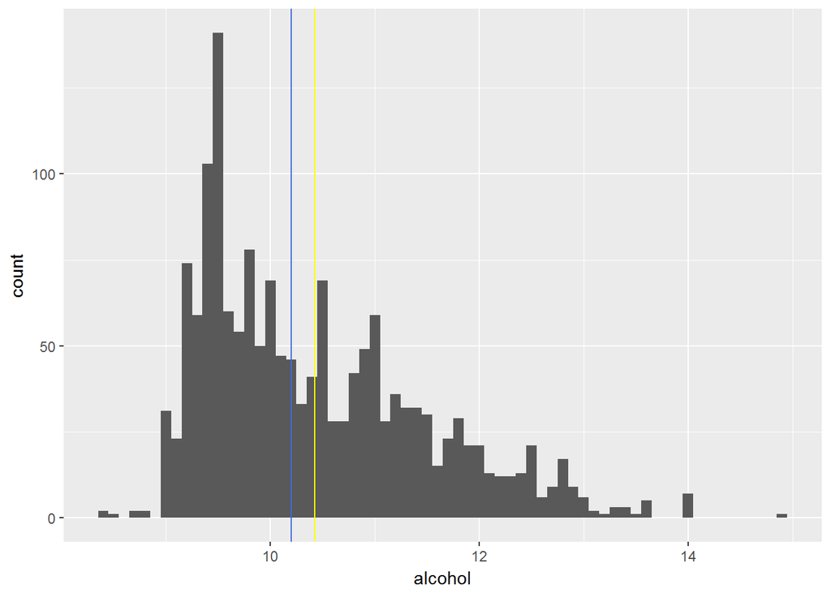

```
##    Min. 1st Qu.  Median    Mean 3rd Qu.    Max.
##    8.40    9.50   10.20   10.42   11.10   14.90
```

Alcohol also shows a positive skew, but not nearly as pronounced as that for Residual Sugar. Since we have nine more elements to review, it might be easier to set them up in a 3x3 grid for convenience:

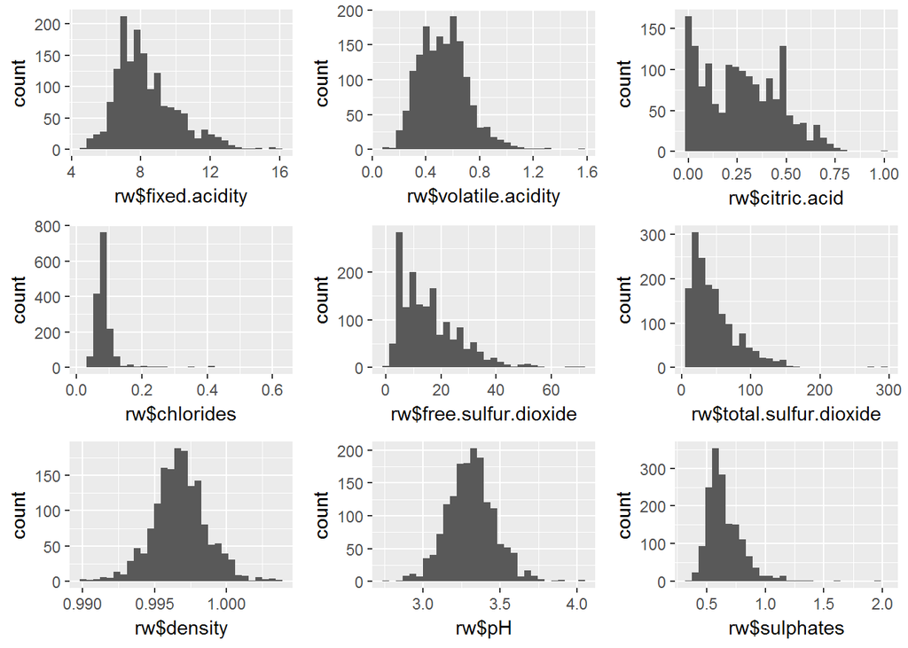

We see that *Density* and *pH* both have what appear to be normal distribution, while the rest show some degree of positive skew, particularly *Chlorides*, which is not only highly skewed, but also has a very narrow range other than the long tail. *Citric Acid* seems to be out of whack, too, with almost a bi-modal distribution with a positive skew thrown in for fun. We’ll take a closer look at both of these. starting with *Citric Acid*

We’ll begin by adjusting bin width to a smaller range:

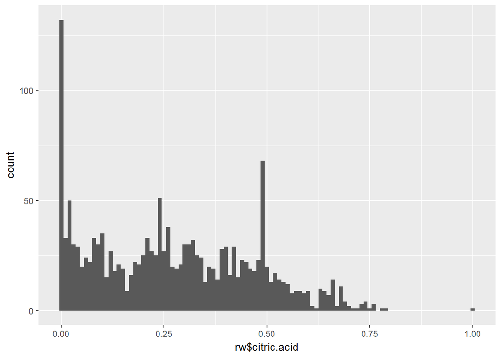

There are an awful lot of wines with 0 g/L of *Citric Acid*, with spikes at around 0.02, 0.24, and 0.49. Maybe adjusting this further by changing the concentration to a logarithmic scale:

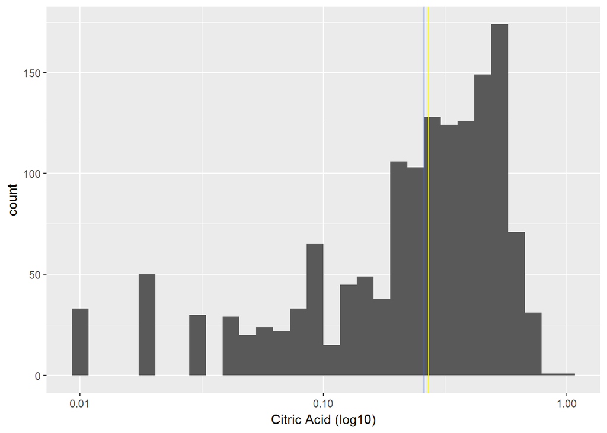

```
##    Min. 1st Qu.  Median    Mean 3rd Qu.    Max.
##   0.000   0.090   0.260   0.271   0.420   1.000
```

with a log scale it seems like this is now a negative skew. There’s definitely something odd going on here, but we’ll move on for now.

Next we’ll start digging into *Chlorides* a bit more to see what may be happening, because it there are quite a few of these trailing way out there. We’ll begin as we did with *Chlorides*, buy just focusing on the bottom 95%:

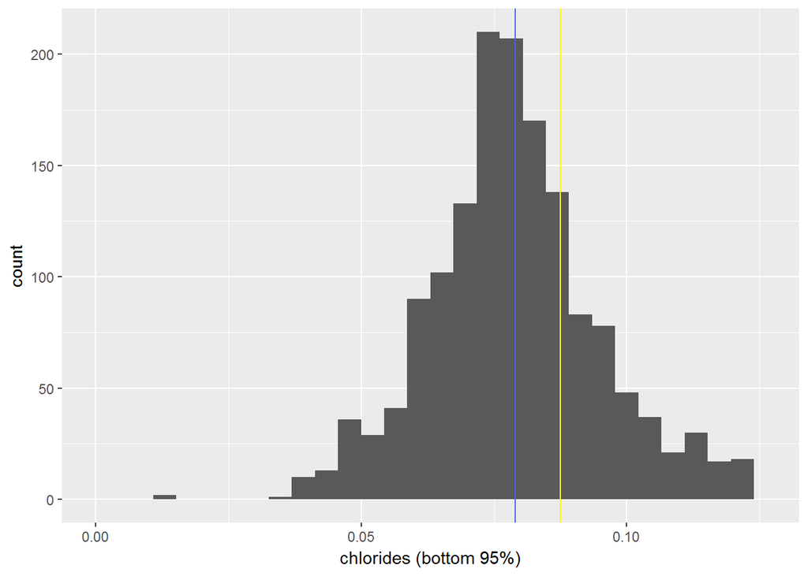

```
##    Min. 1st Qu.  Median    Mean 3rd Qu.    Max.
## 0.01200 0.07000 0.07800 0.07914 0.08800 0.12600
```

Well, it seems there’s a lone sample out on the far low end, so maybe changing this to the middle 95% is a better idea:

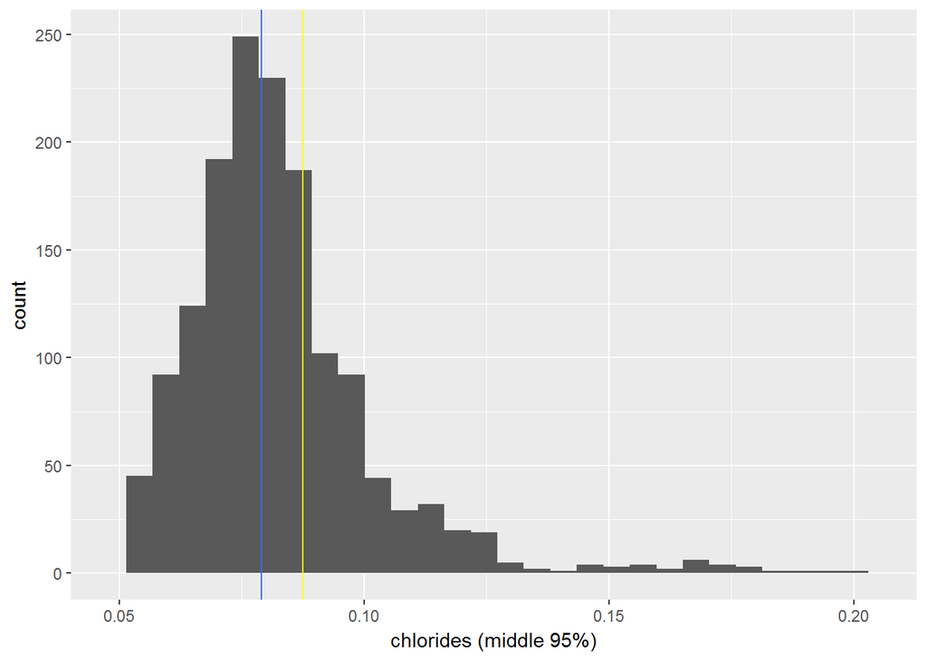

[output not shown]

Clearly there needs to be yet another adjustment, so let’s go ahead and change the *Chloride* scale to a log:

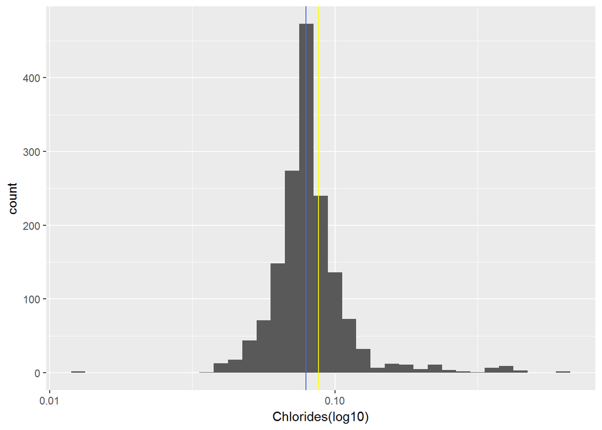

```
##    Min. 1st Qu.  Median    Mean 3rd Qu.    Max.
## 0.01200 0.07000 0.07900 0.08747 0.09000 0.61100
```

Now that the scale is logarithmic, it looks a lot better.

As mentioned earlier, *Density* and *pH* both seem to have normal distribution. It would be nice to check it to confirm:

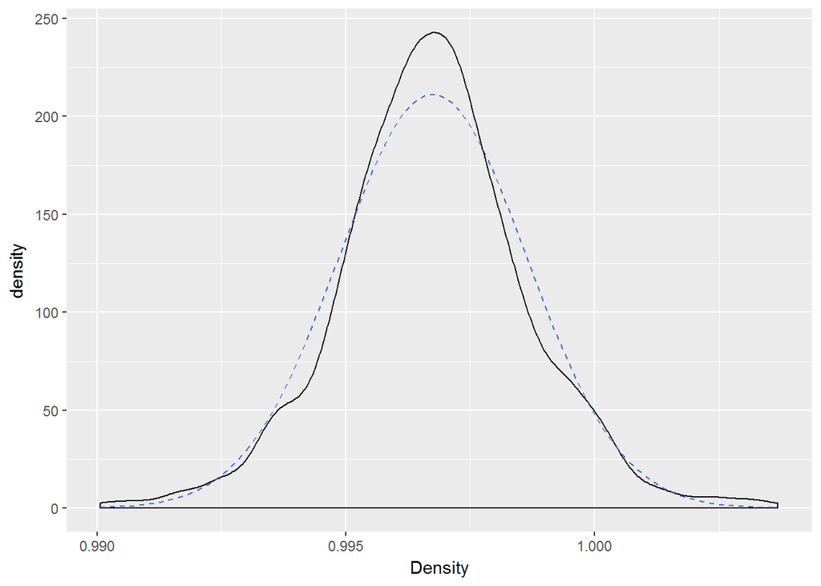

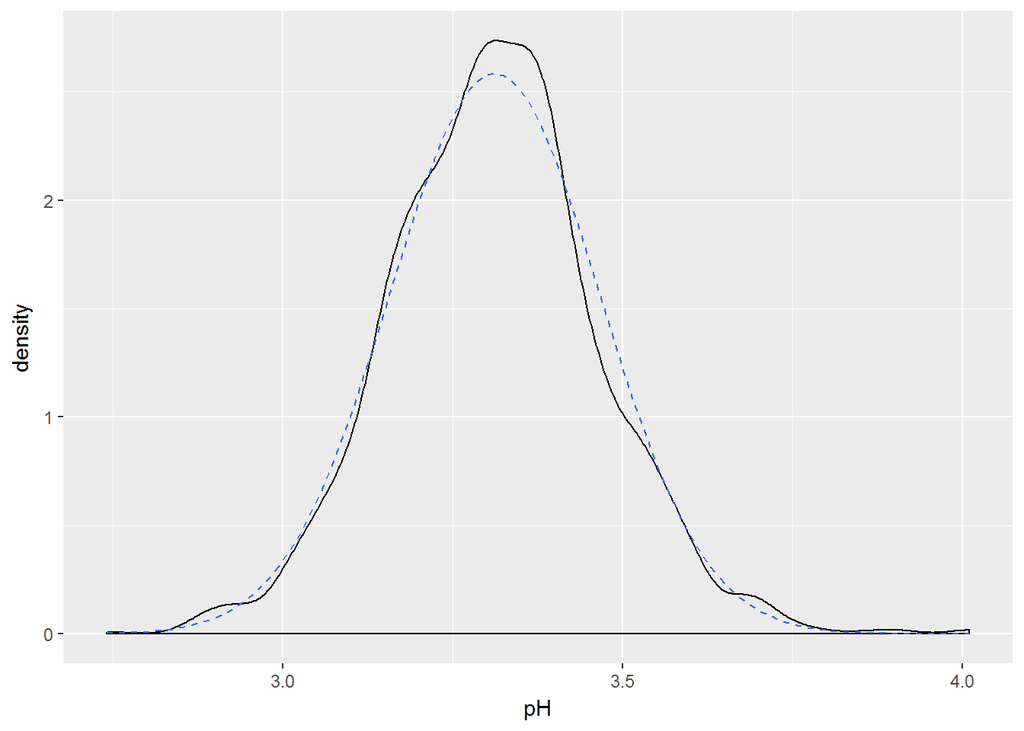

Those are both pretty close curves. For all intents and purposes we can be confident that *Density* and *pH* are normally distributed.

## Univariate Analysis

### What is the structure of your dataset?

The Red Wine Quality dataset contains 12 variables and 1599 observations. Of the variables, 11 are direct measurements of the physical and chemical properties of wine. One variable is *Quality*, which is a subjective score given to the wine as a whole.

Two variables, *Density* and *pH* show normal distributions, Eight, *Residual Sugar*, *Alcohol*, *Fixed Acidity*, *Volatile Acidity*, *Chlorides*, *Free Sulphur Dioxide*, *Total Sulphur Dioxide*, and *Sulphates* all show some degree of positive skew, while *Citric Acid* seems to have an almost bi-modal distribution.

### What is/are the main feature(s) of interest in your dataset?

My hypothesis is that *Alcohol* and *Residual Sugar* are the most important qualities in determining wine quality.

### What other features in the dataset do you think will help support your investigation into your feature(s) of interest?

I’m also of the opinion that Acidity, in the forms of *Volatile*, *Fixed*, and *Citric* Acids as well as *pH* contribute to wine quality.

### Of the features you investigated, were there any unusual distributions? Did you perform any operations on the data to tidy, adjust, or change the form of the data? If so, why did you do this?

# Section 2: Bivariate Plots

We begin by comparing all of the variables against each other in a table:

```
##                      fixed.acidity volatile.acidity citric.acid
## fixed.acidity                1.000           -0.256       0.672
## volatile.acidity            -0.256            1.000      -0.552
## citric.acid                  0.672           -0.552       1.000
## residual.sugar               0.115            0.002       0.144
## chlorides                    0.094            0.061       0.204
## free.sulfur.dioxide         -0.154           -0.011      -0.061
## total.sulfur.dioxide        -0.113            0.076       0.036
## density                      0.668            0.022       0.365
## pH                          -0.683            0.235      -0.542
## sulphates                    0.183           -0.261       0.313
## alcohol                     -0.062           -0.202       0.110
## quality                      0.124           -0.391       0.226
##                      residual.sugar chlorides free.sulfur.dioxide
## fixed.acidity                 0.115     0.094              -0.154
## volatile.acidity              0.002     0.061              -0.011
## citric.acid                   0.144     0.204              -0.061
## residual.sugar                1.000     0.056               0.187
## chlorides                     0.056     1.000               0.006
## free.sulfur.dioxide           0.187     0.006               1.000
## total.sulfur.dioxide          0.203     0.047               0.668
## density                       0.355     0.201              -0.022
## pH                           -0.086    -0.265               0.070
## sulphates                     0.006     0.371               0.052
## alcohol                       0.042    -0.221              -0.069
## quality                       0.014    -0.129              -0.051
##                      total.sulfur.dioxide density     pH sulphates alcohol
## fixed.acidity                      -0.113   0.668 -0.683     0.183  -0.062
## volatile.acidity                    0.076   0.022  0.235    -0.261  -0.202
## citric.acid                         0.036   0.365 -0.542     0.313   0.110
## residual.sugar                      0.203   0.355 -0.086     0.006   0.042
## chlorides                           0.047   0.201 -0.265     0.371  -0.221
## free.sulfur.dioxide                 0.668  -0.022  0.070     0.052  -0.069
## total.sulfur.dioxide                1.000   0.071 -0.066     0.043  -0.206
## density                             0.071   1.000 -0.342     0.149  -0.496
## pH                                 -0.066  -0.342  1.000    -0.197   0.206
## sulphates                           0.043   0.149 -0.197     1.000   0.094
## alcohol                            -0.206  -0.496  0.206     0.094   1.000
## quality                            -0.185  -0.175 -0.058     0.251   0.476
##                      quality
## fixed.acidity          0.124
## volatile.acidity      -0.391
## citric.acid            0.226
## residual.sugar         0.014
## chlorides             -0.129
## free.sulfur.dioxide   -0.051
## total.sulfur.dioxide  -0.185
## density               -0.175
## pH                    -0.058
## sulphates              0.251
## alcohol                0.476
## quality                1.000
```

The number of variables makes this table a bit too much to take in at once, however, a review of the *Quality* column indicates that *Alcohol* (0.476) and *Volatile Acidity* (-0.391) have the closest correlation with wine Quality.

Let’s give a look over at a series of scatterplots:

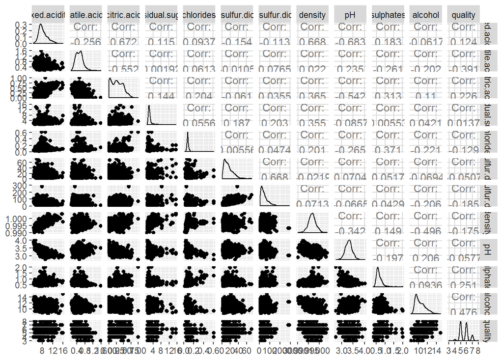

Okay, that’s almost more intimidating than the table. It may be a good idea to trim the number of variables to make this a bit easier to digest. Given the correlations I think it might be good to go back to the table and consider focusing on those variables with the greatest correlation to Quality. With that in mind, I’ll remove *pH*, *Free Sulphur Dioxide*, *Fixed Acidity*, and *Total Sulphur Dioxide* from the matrix. Even though *Residual Sugar* has the lowest correlation to quality in the table, since it was one of the factors I initially considered to be important to quality, I will keep it.

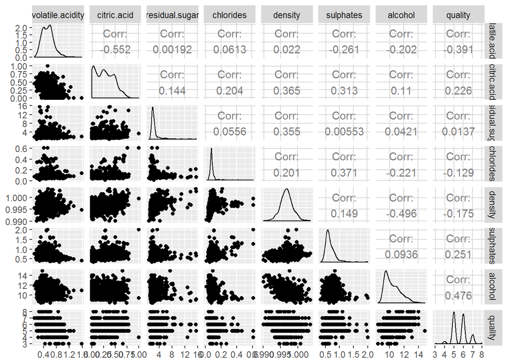

Now that’s much easier to review. *Density* and *Citric Acid* both have some high correlative values with other variables, bu in terms of *Quality* it seems that *Volatile Acid*, *Citric Acid*, *Sulphates* and *Alcohol* are the most relevant, each with a correlation coefficient greater than +/- 0.225

Getting a closer look at these is a good idea. Let’s start with *Alcohol*, which has the highest correlative value at 0.476

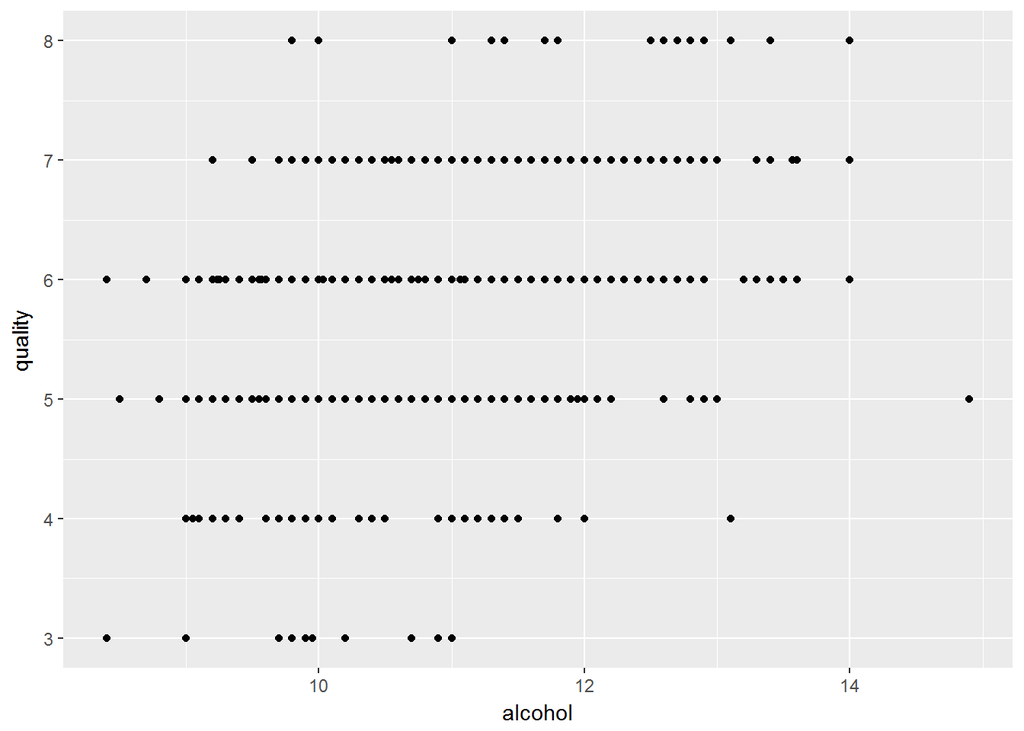

We’ll clean this up a bit and add a trendline:

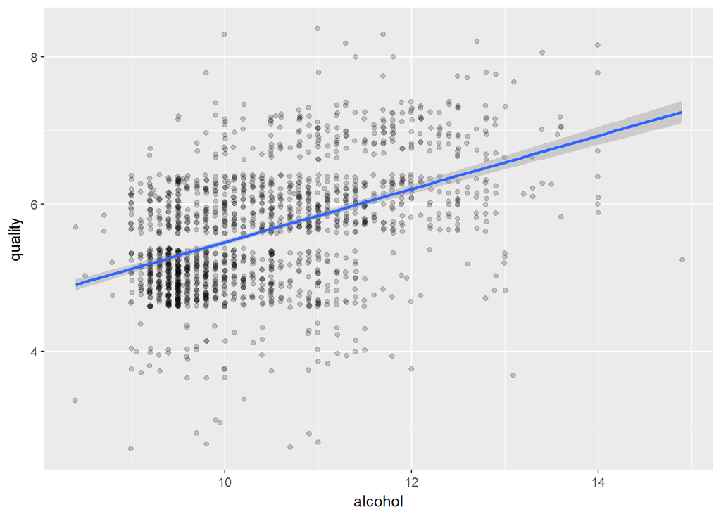

Two things jump out from this: The first is the unambiguous trendline showing an increase in quality with an increase in alcohol, and secondly that there is a very high concentration of wines in the 9-10% Alcohol concentration range.

One of the things that we all should remember from high school chemistry is that alcohol is less dense than water, therefore we would expect wine density to be inversely proportional to alcohol level. And, a look at the table confirms this as *Density* has a correlation of -0.496 with *Alcohol*. Thus, it may be a good idea to take a look at these two variables together:

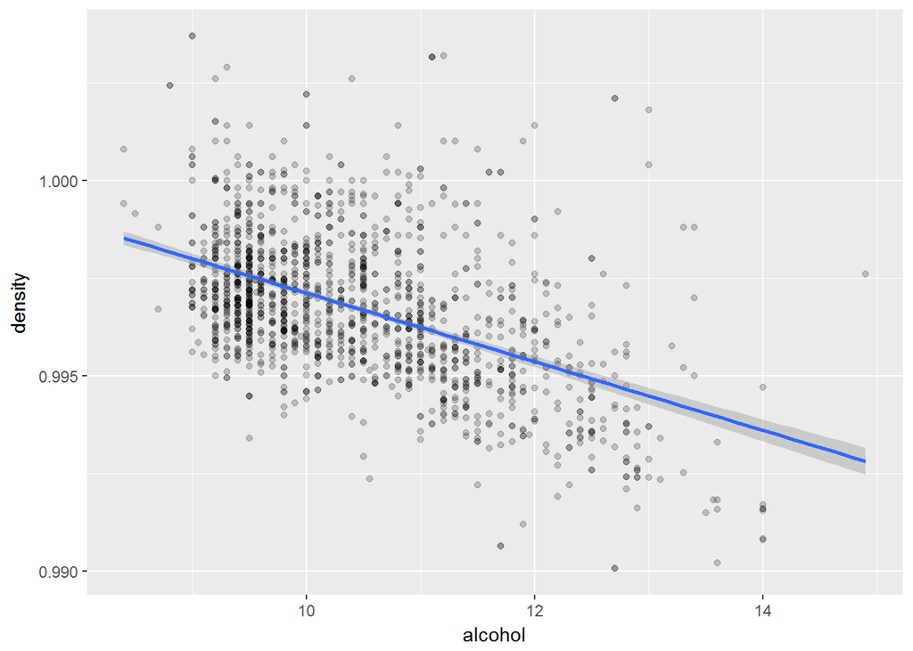

This graph is no surprise. And, given this correlation, let’s look at *Density* and *Qualityl*:

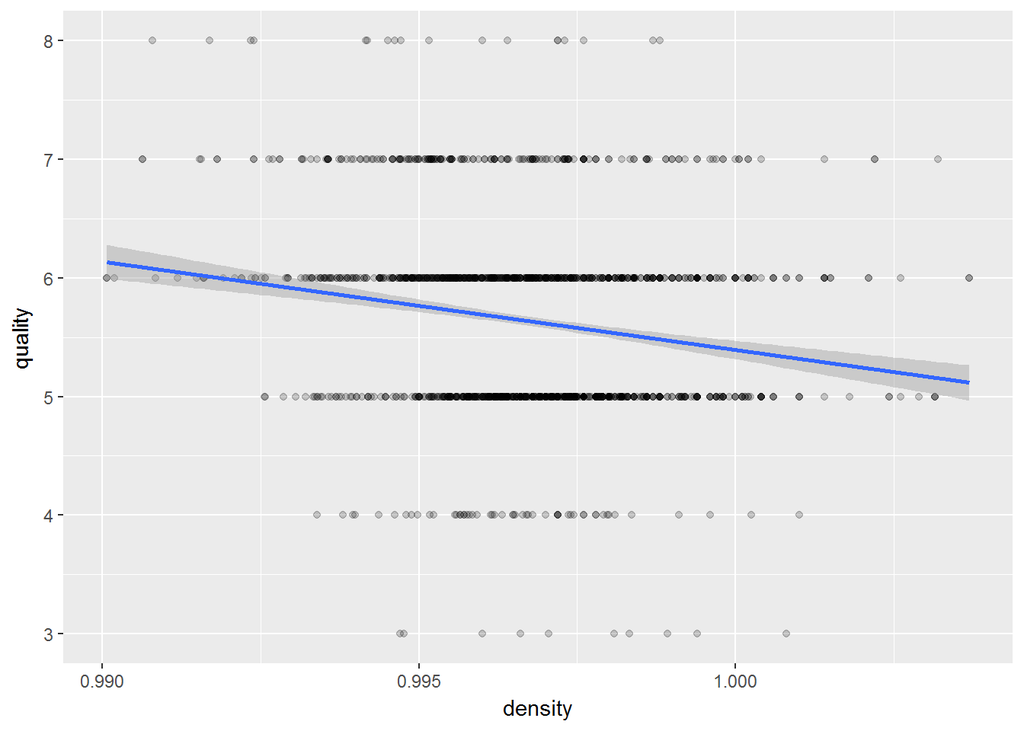

Again, the trendline does seem to be consistent given the *Alcohol* vs *Quality* graph and the relationship between *Density* and *Alcohol*, however, the data points seem to indicate that *Density* isn’t a strong factor.

Aside from *Alcohol*, my initial suspicion was that *Residual Sugar* was an important factor in determining wine quality. Let’s run this to see how it measures against *Quality*:

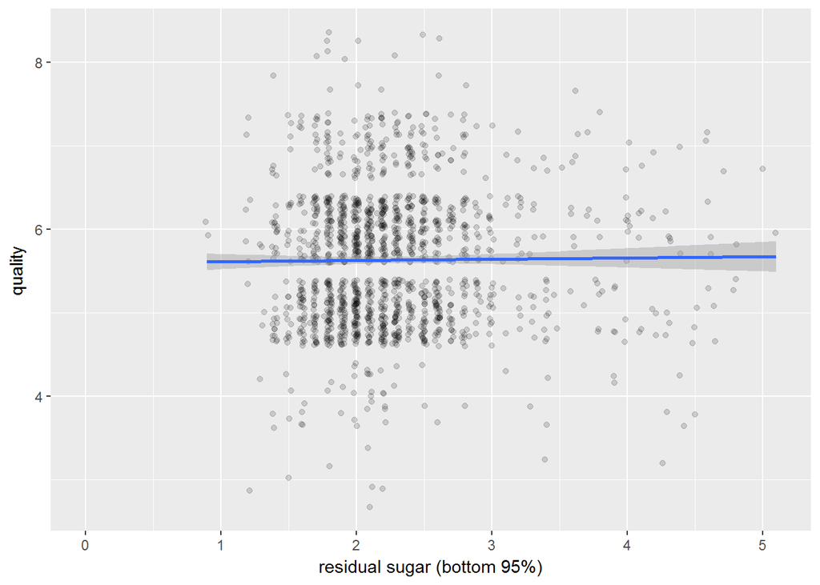

Clearly my suspicion was wrong, because that trendline is pretty flat. And, as it turns out, almost all wines have a concentration of between 1.5 and 2.5 g/L, while higher sugar levels seem to be about evenly distributed among the different quality levels.

My secondary suspicion was that acidity would have some impact on quality. As both the table and the graph matrix showed, *Volatile Acidity* had the second highest correlative score (-0.391) with *Quality*. Let’s give that a look:

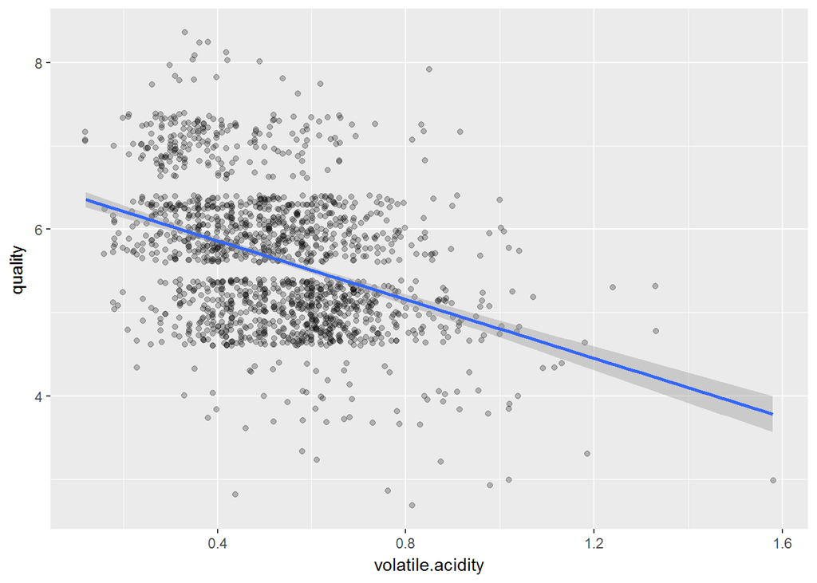

Well, at first look it seems that there is definitely something here, though it appears to be more a matter of high *Volatile Acidity* having a negative impact than anything else, as most of the wines have between 0.3 and 0.6, and seem to be distributed more or less evenly among wines of quality 5 & 6.

Now it’s all fine and good to look at these graphs and see trendlines indicating correlation, but exactly how big an impact do *Alcohol* and *Volatile Acidity* have on the quality of wine? To check that we can do a quick test to find the R-squared value and measure impact. We’ll start with *Alcohol*:

```
##
## Call:
## lm(formula = as.numeric(quality) ~ alcohol, data = rw)
##
## Residuals:
##     Min      1Q  Median      3Q     Max
## -2.8442 -0.4112 -0.1690  0.5166  2.5888
##
## Coefficients:
##             Estimate Std. Error t value Pr(>|t|)
## (Intercept)  1.87497    0.17471   10.73   <2e-16 ***
## alcohol      0.36084    0.01668   21.64   <2e-16 ***
## ---
## Signif. codes:  0 '***' 0.001 '**' 0.01 '*' 0.05 '.' 0.1 ' ' 1
##
## Residual standard error: 0.7104 on 1597 degrees of freedom
## Multiple R-squared:  0.2267, Adjusted R-squared:  0.2263
## F-statistic: 468.3 on 1 and 1597 DF,  p-value: < 2.2e-16
```

We see R-squared indicates a 22.67% impact, which, given the presence of 11 distinct factors, seems to be quite a bit. My original hypothesis was that *Residual Sugar* also was important, though the correlation table/graph seems to deny that. Just for fun, let’s check:

```
##
## Call:
## lm(formula = as.numeric(quality) ~ residual.sugar, data = rw)
##
## Residuals:
##     Min      1Q  Median      3Q     Max
## -2.6609 -0.6334  0.3580  0.3690  2.3729
##
## Coefficients:
##                Estimate Std. Error t value Pr(>|t|)
## (Intercept)    5.616055   0.041616 134.950   <2e-16 ***
## residual.sugar 0.007865   0.014331   0.549    0.583
## ---
## Signif. codes:  0 '***' 0.001 '**' 0.01 '*' 0.05 '.' 0.1 ' ' 1
##
## Residual standard error: 0.8077 on 1597 degrees of freedom
## Multiple R-squared:  0.0001886,  Adjusted R-squared:  -0.0004375
## F-statistic: 0.3012 on 1 and 1597 DF,  p-value: 0.5832
```

```
##
## Call:
## lm(formula = as.numeric(quality) ~ volatile.acidity, data = rw)
##
## Residuals:
##      Min       1Q   Median       3Q      Max
## -2.79071 -0.54411 -0.00687  0.47350  2.93148
##
## Coefficients:
##                  Estimate Std. Error t value Pr(>|t|)
## (Intercept)       6.56575    0.05791  113.39   <2e-16 ***
## volatile.acidity -1.76144    0.10389  -16.95   <2e-16 ***
## ---
## Signif. codes:  0 '***' 0.001 '**' 0.01 '*' 0.05 '.' 0.1 ' ' 1
##
## Residual standard error: 0.7437 on 1597 degrees of freedom
## Multiple R-squared:  0.1525, Adjusted R-squared:  0.152
## F-statistic: 287.4 on 1 and 1597 DF,  p-value: < 2.2e-16
```

Here the R-squared value shows a 15.25% impact. That’s not as big as I would have expected, but then again there are three additional measures of acidity: *Fixed Acidity*, *Citric Acid*, and *pH*. Let’s give those a run:

Fixed Acidity:

```
##
## Call:
## lm(formula = as.numeric(quality) ~ fixed.acidity, data = rw)
##
## Residuals:
##     Min      1Q  Median      3Q     Max
## -2.8248 -0.6061  0.1925  0.4341  2.5550
##
## Coefficients:
##               Estimate Std. Error t value Pr(>|t|)
## (Intercept)    5.15732    0.09789  52.684  < 2e-16 ***
## fixed.acidity  0.05754    0.01152   4.996  6.5e-07 ***
## ---
## Signif. codes:  0 '***' 0.001 '**' 0.01 '*' 0.05 '.' 0.1 ' ' 1
##
## Residual standard error: 0.8016 on 1597 degrees of freedom
## Multiple R-squared:  0.01539,    Adjusted R-squared:  0.01477
## F-statistic: 24.96 on 1 and 1597 DF,  p-value: 6.496e-07
```

Citric Acid

```
##
## Call:
## lm(formula = as.numeric(quality) ~ citric.acid, data = rw)
##
## Residuals:
##     Min      1Q  Median      3Q     Max
## -3.0011 -0.5976  0.1021  0.5057  2.5901
##
## Coefficients:
##             Estimate Std. Error t value Pr(>|t|)
## (Intercept)  5.38172    0.03372 159.610   <2e-16 ***
## citric.acid  0.93845    0.10104   9.288   <2e-16 ***
## ---
## Signif. codes:  0 '***' 0.001 '**' 0.01 '*' 0.05 '.' 0.1 ' ' 1
##
## Residual standard error: 0.7869 on 1597 degrees of freedom
## Multiple R-squared:  0.05124,    Adjusted R-squared:  0.05065
## F-statistic: 86.26 on 1 and 1597 DF,  p-value: < 2.2e-16
```

pH

```
##
## Call:
## lm(formula = as.numeric(quality) ~ pH, data = rw)
##
## Residuals:
##     Min      1Q  Median      3Q     Max
## -2.6817 -0.6394  0.3032  0.3878  2.4874
##
## Coefficients:
##             Estimate Std. Error t value Pr(>|t|)
## (Intercept)   6.6359     0.4332  15.320   <2e-16 ***
## pH           -0.3020     0.1307  -2.311    0.021 *
## ---
## Signif. codes:  0 '***' 0.001 '**' 0.01 '*' 0.05 '.' 0.1 ' ' 1
##
## Residual standard error: 0.8065 on 1597 degrees of freedom
## Multiple R-squared:  0.003333,   Adjusted R-squared:  0.002709
## F-statistic:  5.34 on 1 and 1597 DF,  p-value: 0.02096
```

### Something in the Acid?

One of the things I noticed when reviewing both the graph matrix and the correlation table was that *pH* had inconsistent correlation with the other three acid components. Since pH is a general measure of acidity with an inverse relation between pH measurement and degree of acidity, one would expect a negative correlation between *pH* and *Volatile*, *Fixed*, and *Citric Acid*. However, *pH* is actually somewhat positively correlated with *Volatile Acidity*, with a correlation factor of 0.235. How can this be?

My suspicion is the presence of Simpson’s Paradox, which I will check now:

[output not shown]

[output not shown]

[output not shown]

[output not shown]

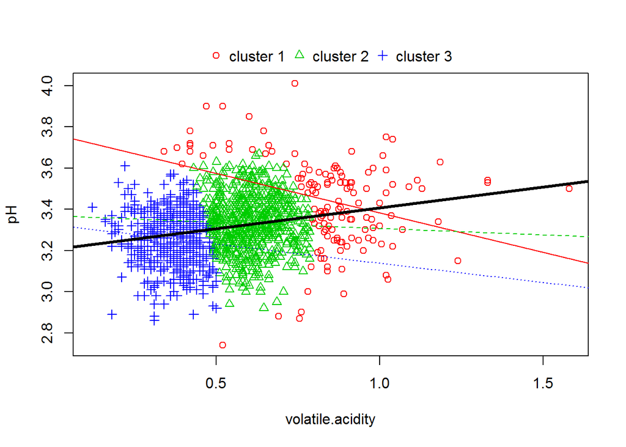

Well, look at that! *Volatile Acidity* is comprised of three separate grous, each of which shows a negative correlation with *pH*, but when aggregated has a positive correlation. Simpson’s confirmed!

And, just for grins and giggles, let’s run a graph matrix of just the acids to see how they all relate to one another:

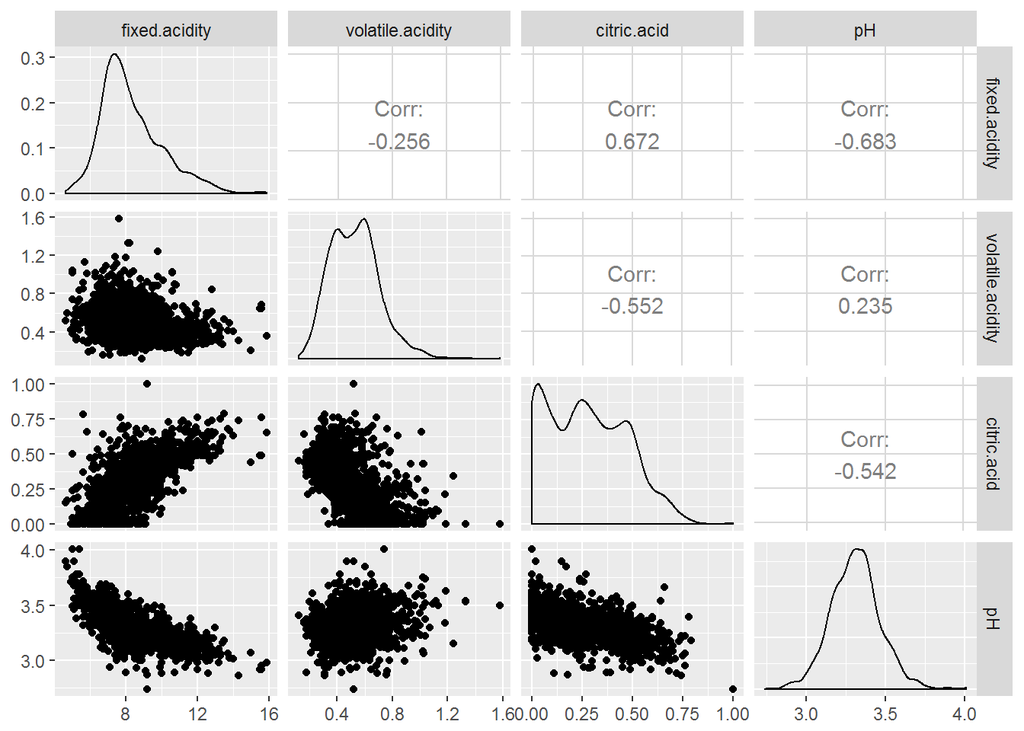

## Bivariate Analysis

### Talk about some of the relationships you observed in this part of the investigation. How did the feature(s) of interest vary with other features in the dataset?

My initial hypothesis was that Alcohol and Sugar were the two most important factors in determining wine quality. It turns out I was half-right. Alcohol appears to be the single biggest factor, contributing about 22.5% to overall quality, while sugar is irrelevant, at only 0.019%.

### Did you observe any interesting relationships between the other features (not the main feature(s) of interest)?

Looking at the relationships between the factors I found that there was a Simpson’s Paradox hiding in the acids. As we all know from high school chemistry, pH is a direct measurement of acidity, with the lower the pH the more acidic. Yet the relationship between *pH* and *Volatile Acidity* showed a positive correlation - which would mean either something odd was happening in *Volatile Acidity*, or there is something about wine that messes up the pH-Acid relationship. A look into it showed that *Volatile Acidity* was actually an aggregation of three separate subsets of acids, each of which was negatively correlated with *pH*, but which combined gave a false positive correlation.

How cool is it to find something like that hiding in your wine?

### What was the strongest relationship you found?

As mentioned several times eariler, the two factors most strongly correlated with *Quality* were *Alcohol* and *Volatile Acidity*. Let’s go ahead and plot this:

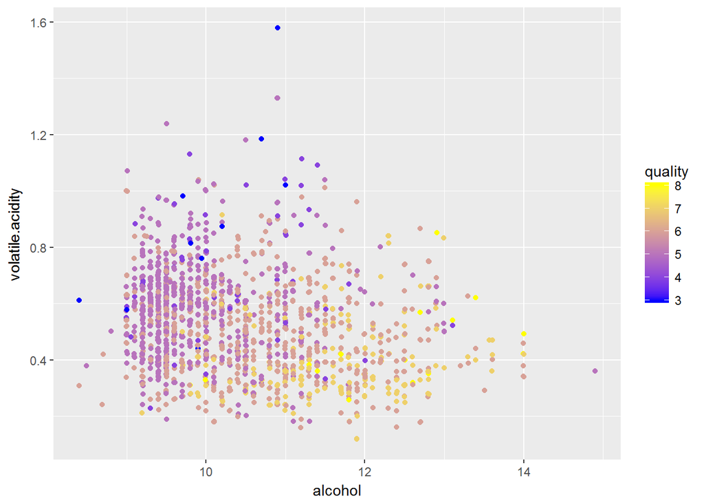

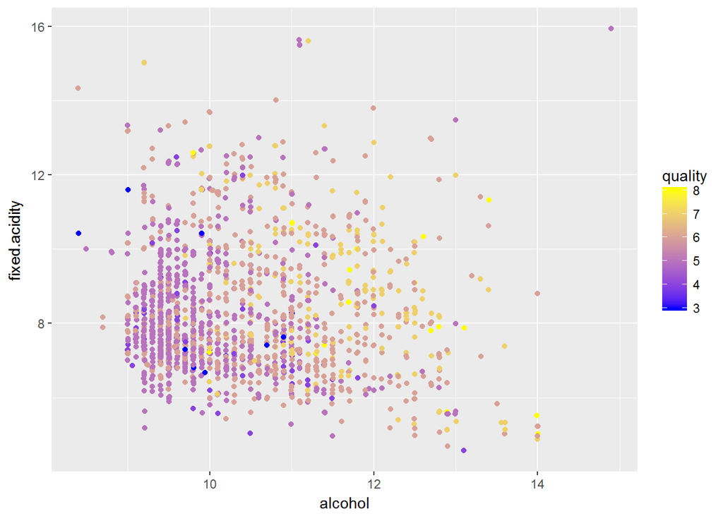

This is similar to the previous graph, and again follows what we would expect given the results obtained so far. May as well do the remaining acidity measurements just to be thorough.

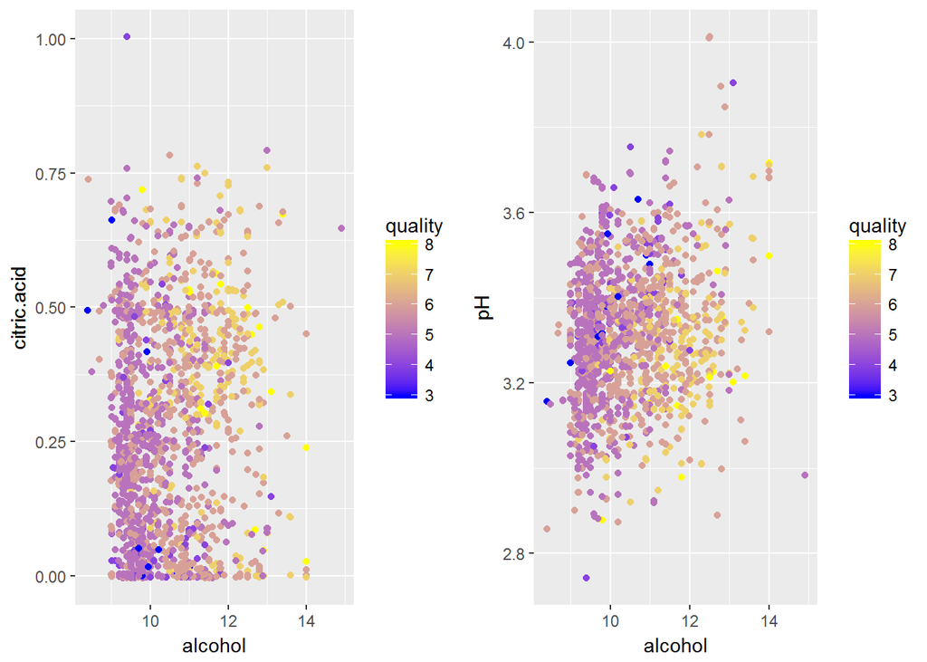

Okay, these are a bit squeezed, but there is still a pattern visible for *Citric Acid*, while it seems that *pH* isn’t really important.

Now, even though we’ve already beaten the idea that *Residual Sugar* has any impact, since it was part of my initial hypothesis, I feel duty-bound to include an analysis using it and *Alcohol*:

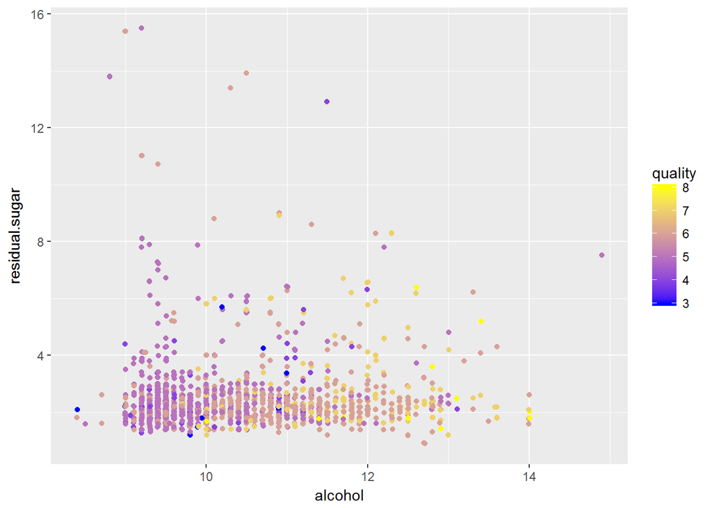

The lack of any clear pattern shouldn’t come as any surprise.

Curiosity has me reviewing the correlation table, where I notice that the highest correlative factor between un-related elements (i.e. not acids to acids, or free and total sulfur dioxide) is between *Density* and *Fixed Acidity* with a value of 0.668. Naturally, I have to check those out and see whether their interplay has anything to do with quality at all:

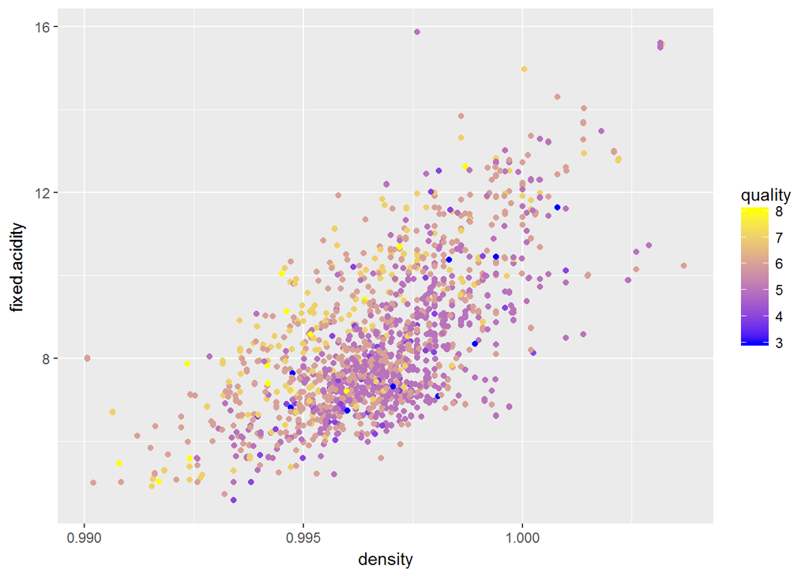

This has an interesting result, as it appears that *Fixed Acidity* and *Density* have a very tight relationship to one another in terms of quality, and if Density increases without a corresponding increase in Fixed Acidity, quality suffers.

Interesting.

Lastly, it may be valuable to consider how some of the thus far neglected factors, such as sulphates, chlorides, and free & total sulfur dioxide may be involved. I’ll begin by running each of these along with alcohol:

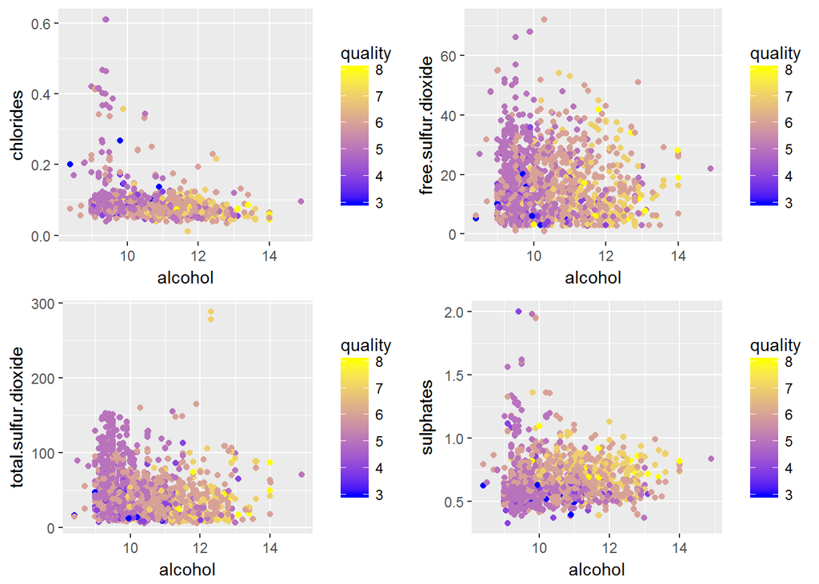

It’s hard to see for sure, but it appears that none of these factors have much impact.

Next I’ll run these with *Volatile Acidity*:

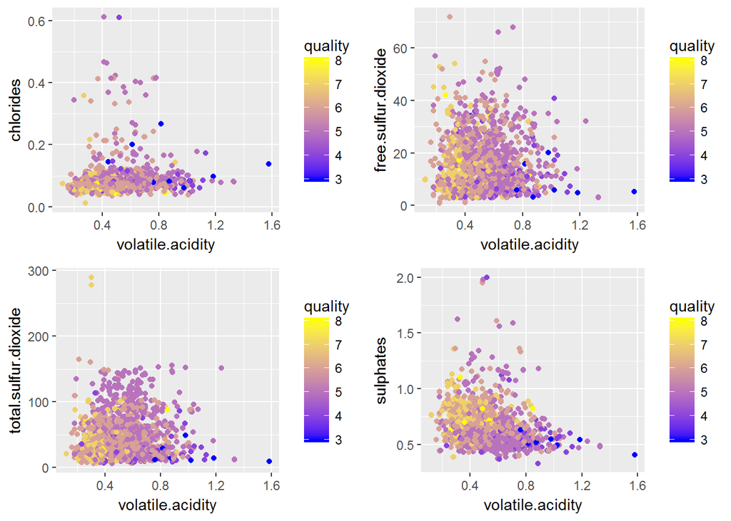

Once again, it appears that there is really no impact.

## Multivariate Analysis

### Talk about some of the relationships you observed in this part of the investigation. Were there features that strengthened each other in terms of looking at your feature(s) of interest?

These plots helped underscore the importance of acidity in the quality of wine.

### Were there any interesting or surprising interactions between features?

The complex relationship that *Density* has with *Fixed Acidity* is very interesting, as it indicates that in order for wine to rate as high quality, the Fixed Acidity has to increase in value (i.e. become less acidic) as Density increases.

# Section 4: Final Plots and Summary

### Plot One

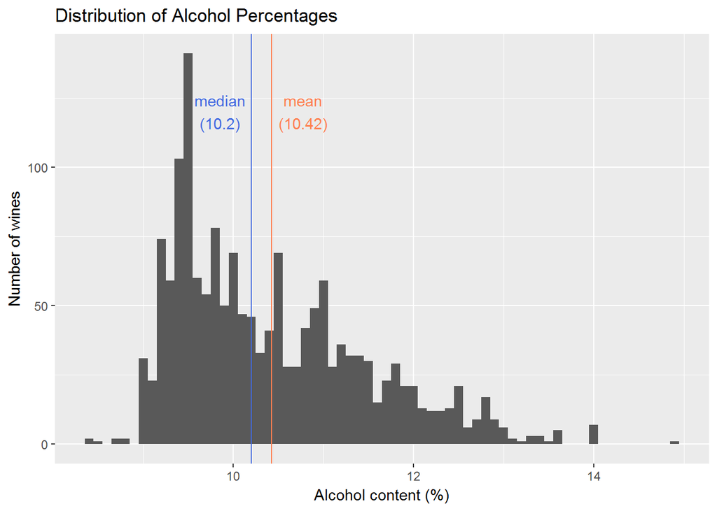

### Description One

Alcohol content in wine shows a positive skew (i.e. the Mean lies at a higher value than the Median, and there is a long tail trailing toward higher values). The majority of wines have alcohol content between 9 and 11%, with very few greater than 12%

### Plot Two

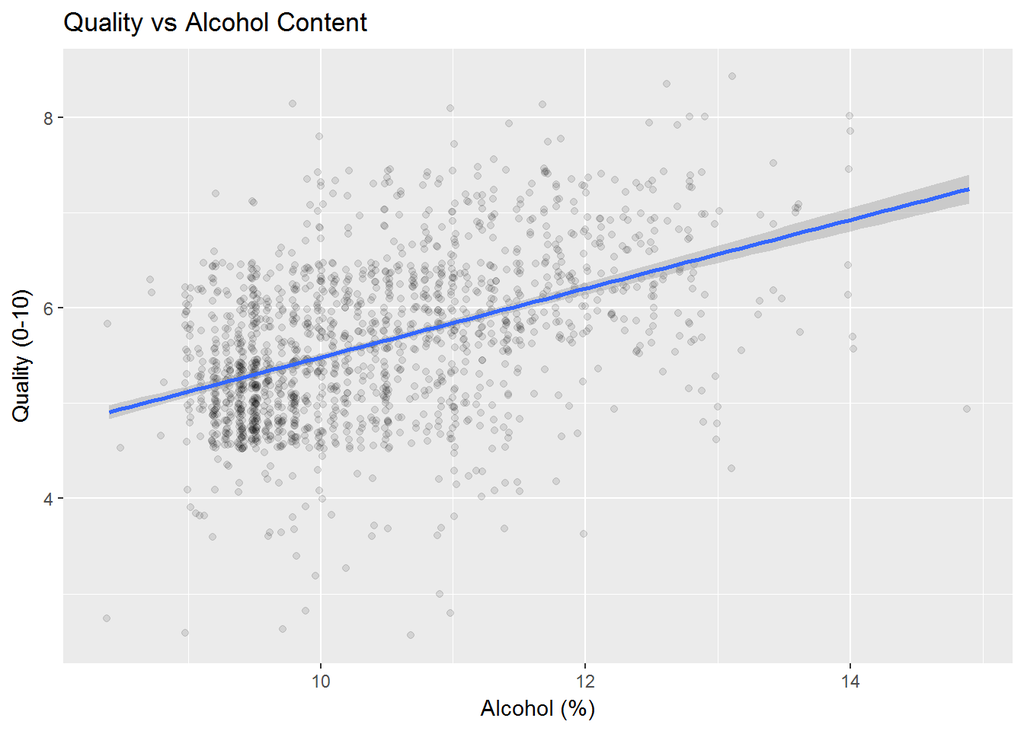

### Plot Three

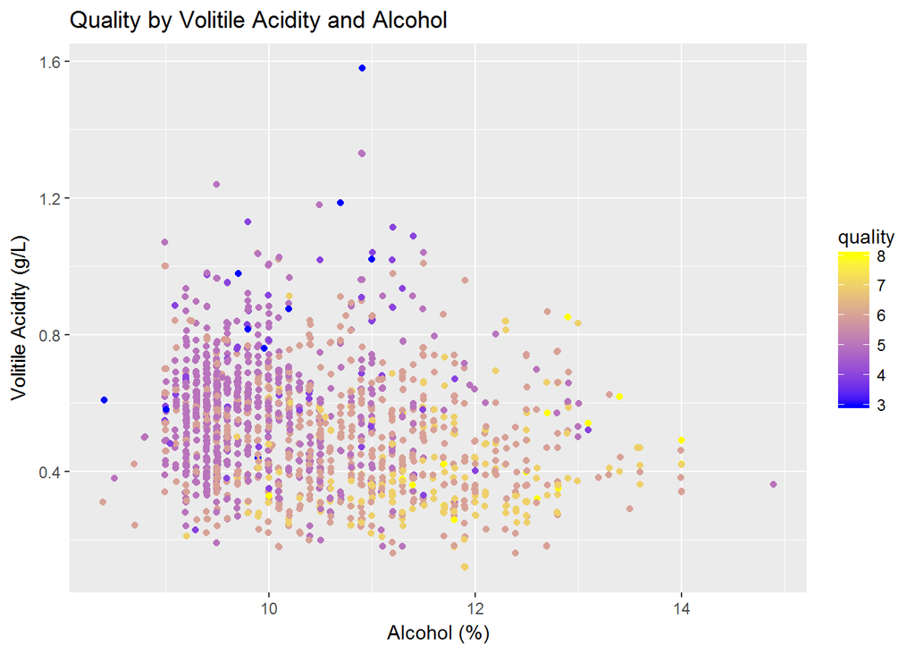

### Description Three

This provides a clear view of the close relationship between Alcohol and Volatile Acidity on quality, where quality increases when volatile acidity is low and alcohol increases.

# Section 5: Reflection

I approached this analysis as someone who enjoys red wine on occasion, but who has no knowledge or experience in determining quality beyond the most basic subjective test of whether I liked it or not. However, I also knew that there existed properties within the wine that affected the overall quality, and that how those worked to make a wine good or bad was objective.

With that in mind, I first took note of the eleven properties measured: four measurements of differng acidic qualities, two measurements of sulfur dioxide and related sulphates, density and alcohol, sugars, and chlorides. Based on my limited knowledge of wines, my initial suspicion was that alcohol and sugars were the most important factors in quality, with acids playing a secondary role.

The first step in checking my hypothesis was a review of the descriptive statistics and distribution of each element. This showed that, for the most part, all had some degree of positive skew, other than *Density* and *pH*, which had normal distribution, and *Citric Acid*, which ad a very strange bi-modal distribution with a positive skew.

The next step was to do bi-variate analysis to look for initial correlation between the factors, which showed that while alcohol did have a correlation to quality, sugar did not, and that acids may play a bigger role than intended. However, it also exposed a puzzling result where *pH* seemed to have a positive correlation to *Volatile Acidity*, rather than the negative correlation expected. A bit of digging confirmed the presence of Simpson’s Paradox to explain this strange relationship.

The multivariate analysis confirmed that alcohol and acidity are the primary factors in determining quality, though the interplay between them is complicated. Further, while the other elements (such as sulphates or chlorides) do not appear to have an obvious role in quality, there may be relationships and interactions which are present, but which I could not determine.

If I were to continue in this analysis, I think I would focus on the more odd elements, such as Citric Acid. These certainly play a role in wine quality, and I would be curious to understand how. Further, this dataset covered generic “Red” wine. And as we know, Red wine contains many different types, such as Cabernet, Pinot Noir, Sangiovese, Merlot, Malbec, etc. These different wines have different characteristics, and the components of what makes a good Pinot Noir may be very different than what makes a good Sangiovese or a good Malbec. Getting a more precise dataset, in which wine varietals are identified, would be quite interesting.